# STAT 443 GROUP 7 PROJECT REPORT

Xinjie Qiao, Catherine Zhou, Zoe Zou

2022-12-02

## Import Data and Analysis

```r
data <- read.csv("Data_Group2.csv", header=T)[c("Date", "Switzerland.CHF.")]
head(data)
```

```
##         Date Switzerland.CHF.
## 1 31-01-1979            379.3
## 2 28-02-1979            413.6
## 3 30-03-1979            406.2
## 4 30-04-1979            420.0
## 5 31-05-1979            478.0
## 6 29-06-1979            457.7
```

```r
price <- ts(data$Switzerland.CHF., start=c(1979, 1), end=c(2021, 7), frequency=12)
time <- time(price)
summary(price)
```

```
##    Min. 1st Qu.  Median    Mean 3rd Qu.    Max.
##   379.3   501.6   698.2   826.1  1127.0  1787.5
```

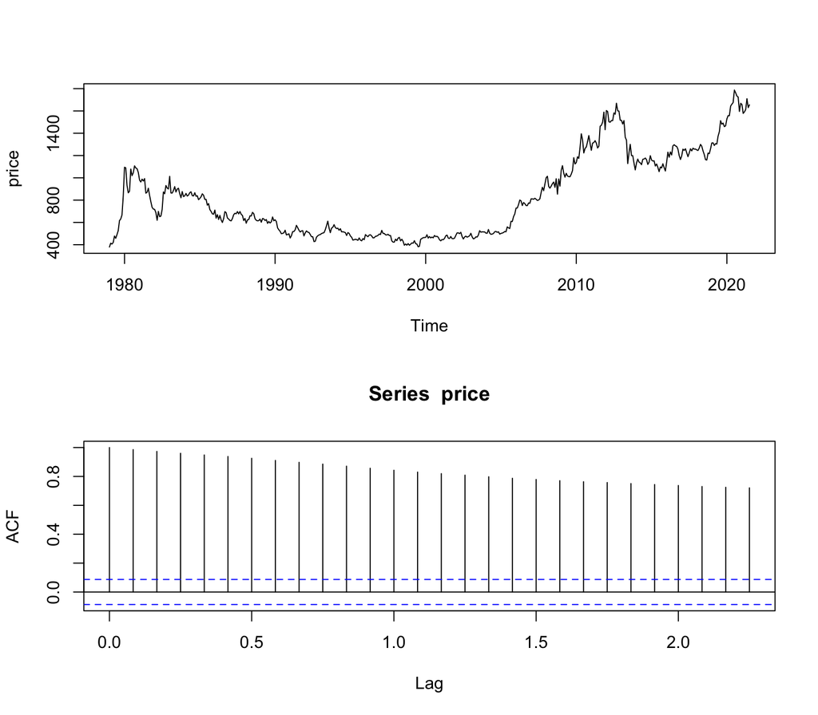

```r
par(mfrow=c(2,1))
ts.plot(price)
acf(price)
```

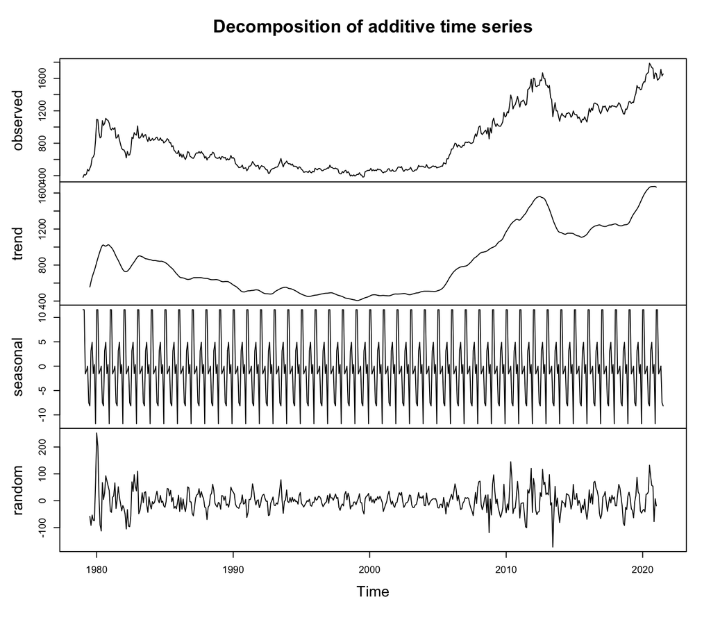

```r
decompose.add <- decompose(price, type="additive")
decompose.mult <- decompose(price, type="multiplicative")
plot(decompose.add)
```

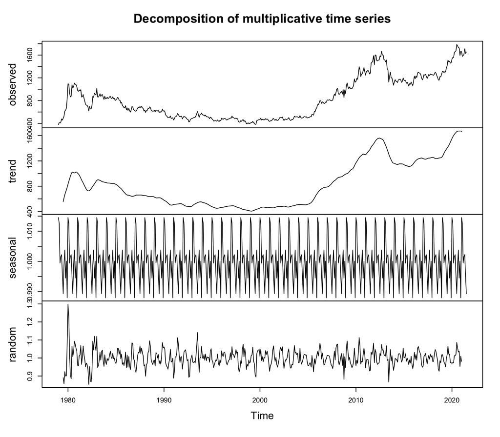

```r
plot(decompose.mult)
```

The Fligner-Killeen test result has a very small p-value, which rejects the hypothesis that our data has constant variance.

Hence, we conclude that our data is non-stationary with strong trend and non-constant variance.

Then, we split our data into training (90% of the data) and test sets (10% of the data).

```r
training.price = window(price, start=c(1979,1), end=c(2017,3), frequency=12)
training.time = window(time, start=c(1979,1), end=c(2017,3), frequency=12)
test.price = window(price, start=c(2017, 3), frequency=12)
test.time = window(time, start=c(2017, 3), frequency=12)
test = data.frame(time=test.time)
training <- data.frame(price=training.price, time=training.time)
df <- data.frame(price=price, time=time)

reg.idx = sample(1:length(price), 53)
reg.training.price = price[-reg.idx]
reg.training.time = time[-reg.idx]
reg.test.price = price[reg.idx]
reg.test.time = time[reg.idx]
reg.train = data.frame(price=reg.training.price, time=reg.training.time)
reg.test = data.frame(time=reg.test.time)
```

Now, we will use power transformation to make variance constant.

```r
library(MASS)
## non-constant variance
seg = factor(c(rep(1:4, each=90), rep(5, 99)))
fligner.test(training.price, seg)
```

```
##
##  Fligner-Killeen test of homogeneity of variances
##
## data:  training.price and seg
## Fligner-Killeen:med chi-squared = 80.736, df = 4, p-value < 2.2e-16
```

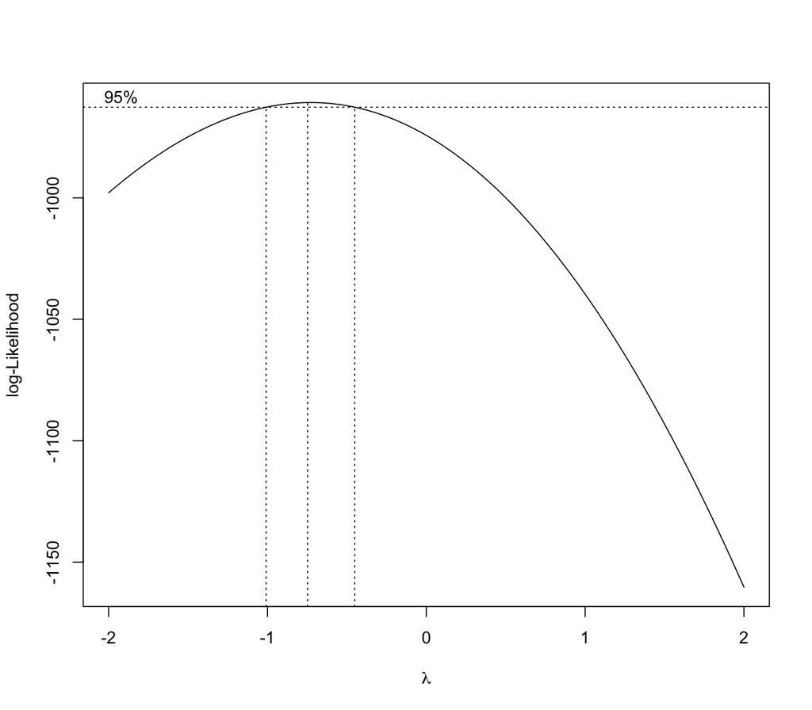

```r
power.alpha <- c(-2,-1.5,-1,-0.5,0,0.5,1.5,2)
bx = boxcox(lm(training.price~1), lambda=power.alpha)
```

```r
f.p <- c()
for (a in power.alpha) {
  if (a == 0) {
    y.star = log(training.price)
  } else {
    y.star = training.price^a
  }
  f.test = fligner.test(y.star, seg)
  f.p = c(f.p, f.test$p.value)
}
f.p
```

```
## [1] 3.663350e-26 3.285780e-21 1.120266e-16 1.339796e-12 1.706958e-11
## [6] 4.735416e-13 4.213607e-23 1.728053e-29
```

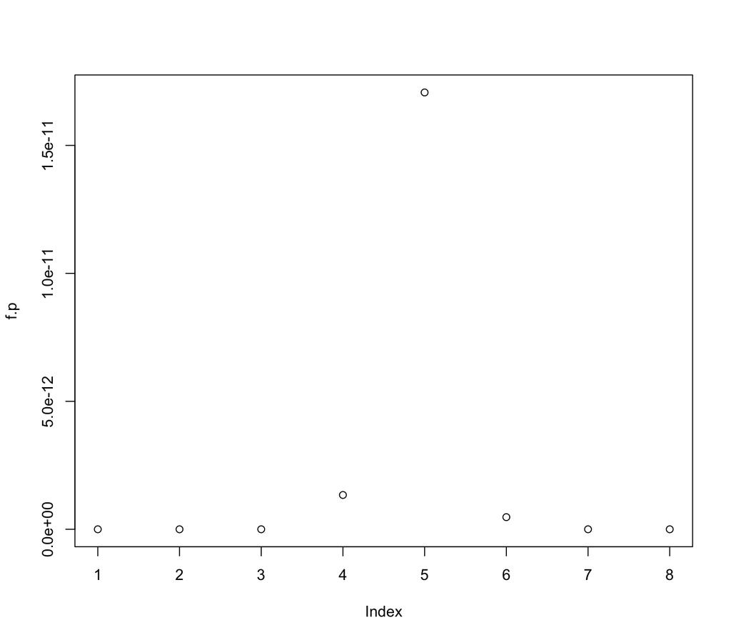

```r
plot(f.p)
abline(h=0.1, col="red")
```

```r
print(power.alpha[which(f.p>0.1)])
```

```
## numeric(0)
```

```r
power.alpha.opt = bx$x[which.max(bx$y)]
training.price.star = training.price^power.alpha.opt
test.price.star = test.price^power.alpha.opt
price.star = price^power.alpha.opt
fligner.test(training.price.star, seg)
```

```
##
##  Fligner-Killeen test of homogeneity of variances
##
## data:  training.price.star and seg
## Fligner-Killeen:med chi-squared = 70.43, df = 4, p-value = 1.841e-14
```

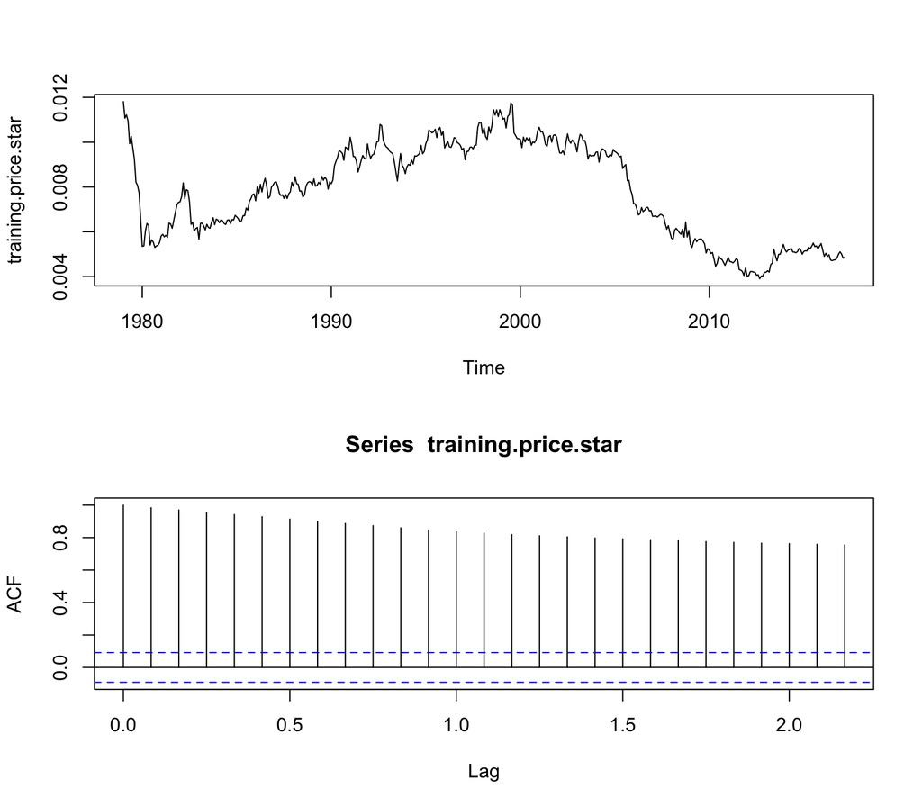

```r
par(mfrow=c(2,1))
ts.plot(training.price.star)
acf(training.price.star)
```

### Regression

We will use polynomial regression (without regularization) first, and then Ridge, LASSO, and Elastic Net as regularized models to fit the model on the data.

```r
degrees <- c(2:15)
MSE <- function(y, yhat) {
  mean((y-yhat)^2)
}
# create fit models with different degrees
poly.mse = c()
for (d in degrees) {
  model = lm(price ~ poly(as.vector(time), d), data=reg.train)
  pred = predict.lm(model, reg.test, interval = "none")
  mse = MSE(reg.test.price, pred)
  poly.mse = c(poly.mse, mse)
}
print(data.frame(degree=degrees, MSE=poly.mse))
```

```
##    degree       MSE
## 1       2 43962.031
## 2       3 41332.929
## 3       4 30649.769
## 4       5 28497.442
## 5       6 26484.795
## 6       7 15323.576
## 7       8 14060.726
## 8       9 14161.299
## 9      10  9676.817
## 10     11  9733.124
## 11     12  9744.475
## 12     13  9421.467
## 13     14  9504.338
## 14     15  8923.381
```

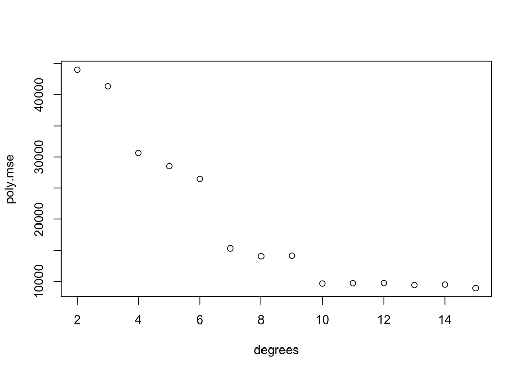

```r
poly.opt = degrees[which.min(poly.mse)]
plot(degrees, poly.mse)
```

```r
print(paste("Degree of the most optimal polynomial is: ", poly.opt))
```

```
## [1] "Degree of the most optimal polynomial is:  15"
```

```r
poly.model = lm(price ~ poly(as.vector(time), poly.opt), data=df)
summary(poly.model)
```

```
##
## Call:
## lm(formula = price ~ poly(as.vector(time), poly.opt), data = df)
##
## Residuals:
##      Min       1Q   Median       3Q      Max
## -245.850  -41.841    2.077   43.388  292.375
##
## Coefficients:
##                                    Estimate Std. Error t value Pr(>|t|)
## (Intercept)                         826.123      3.418 241.701  < 2e-16 ***
## poly(as.vector(time), poly.opt)1   5147.399     77.264  66.621  < 2e-16 ***
## poly(as.vector(time), poly.opt)2   5118.147     77.264  66.242  < 2e-16 ***
## poly(as.vector(time), poly.opt)3   -686.698     77.264  -8.888  < 2e-16 ***
## poly(as.vector(time), poly.opt)4  -2017.257     77.264 -26.109  < 2e-16 ***
## poly(as.vector(time), poly.opt)5   1069.458     77.264  13.842  < 2e-16 ***
## poly(as.vector(time), poly.opt)6   1062.877     77.264  13.756  < 2e-16 ***
## poly(as.vector(time), poly.opt)7   1816.501     77.264  23.510  < 2e-16 ***
## poly(as.vector(time), poly.opt)8   -500.408     77.264  -6.477 2.27e-10 ***
## poly(as.vector(time), poly.opt)9   -706.993     77.264  -9.150  < 2e-16 ***
## poly(as.vector(time), poly.opt)10 -1097.739     77.264 -14.208  < 2e-16 ***
## poly(as.vector(time), poly.opt)11   173.509     77.264   2.246   0.0252 *
## poly(as.vector(time), poly.opt)12     1.520     77.264   0.020   0.9843
## poly(as.vector(time), poly.opt)13   480.423     77.264   6.218 1.07e-09 ***
## poly(as.vector(time), poly.opt)14  -122.676     77.264  -1.588   0.1130
## poly(as.vector(time), poly.opt)15  -390.158     77.264  -5.050 6.23e-07 ***
## ---
## Signif. codes:  0 '***' 0.001 '**' 0.01 '*' 0.05 '.' 0.1 ' ' 1
##
## Residual standard error: 77.26 on 495 degrees of freedom
## Multiple R-squared:  0.9566, Adjusted R-squared:  0.9553
## F-statistic:   728 on 15 and 495 DF,  p-value: < 2.2e-16
```

```r
poly.pred = predict.lm(poly.model, interval = "none")
poly.MSE = MSE(price, poly.pred)
```

Therefore, we try to fit the model by regression with regularization, i.e. Ridge, LASSO, or Elastic Net models, and use a 10-fold cross validation to find the best degree and $\lambda$ value.

```r
library(glmnet)
```

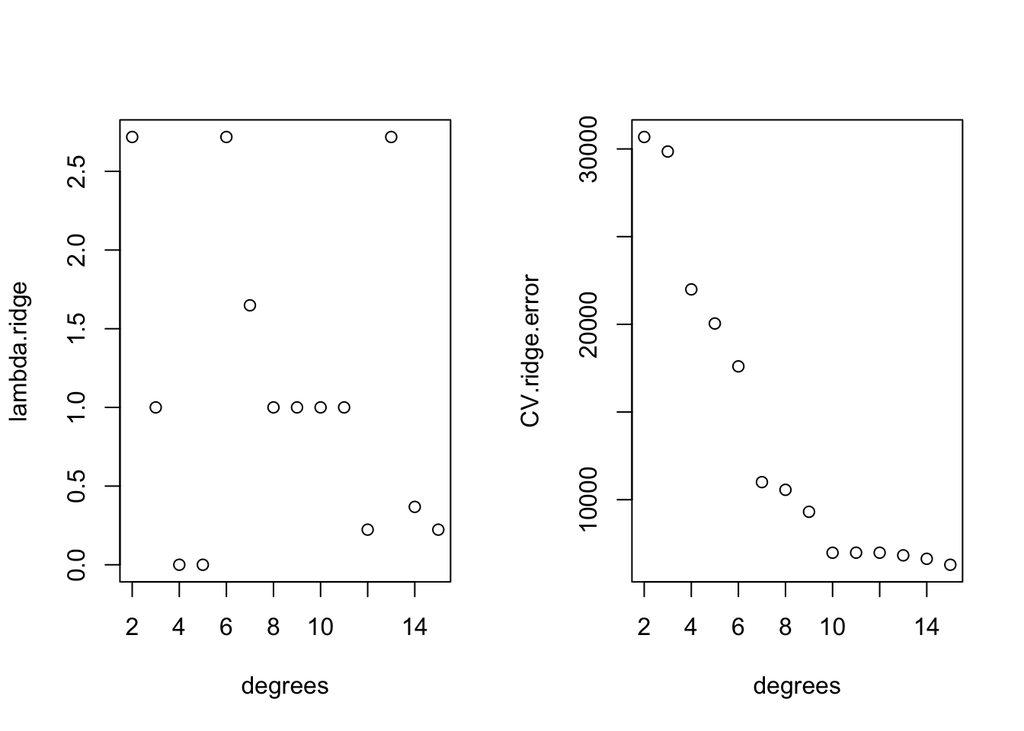

```r
# possible lambda values
Log.Lambda.Seq = c(seq(-10,10,by=0.5))
Lambda.Seq = exp(Log.Lambda.Seq)
set.seed(443)

## RIDGE
lambda.ridge = c()
CV.ridge.error = c()
for (p in degrees) {
  X = poly(as.vector(time), degree=p, simple=T)
  CV = cv.glmnet(X, as.vector(price), alpha=0, lambda=Lambda.Seq,
                 standardize = T, family = "gaussian")
  lambda.ridge = c(lambda.ridge, CV$lambda.min)
  CV.ridge.error = c(CV.ridge.error, CV$cvm[CV$index[1,1]])
}

par(mfrow=c(1,2))
plot(degrees, lambda.ridge)
plot(degrees, CV.ridge.error)
```

```r
degree.ridge.opt = degrees[which.min(CV.ridge.error)]
lambda.ridge.opt = lambda.ridge[which.min(CV.ridge.error)]
sprintf("The best ridge model is at degree %d with lambda %.4f", degree.ridge.opt, lambda.ridge.opt)
```

```
## [1] "The best ridge model is at degree 15 with lambda 0.2231"
```

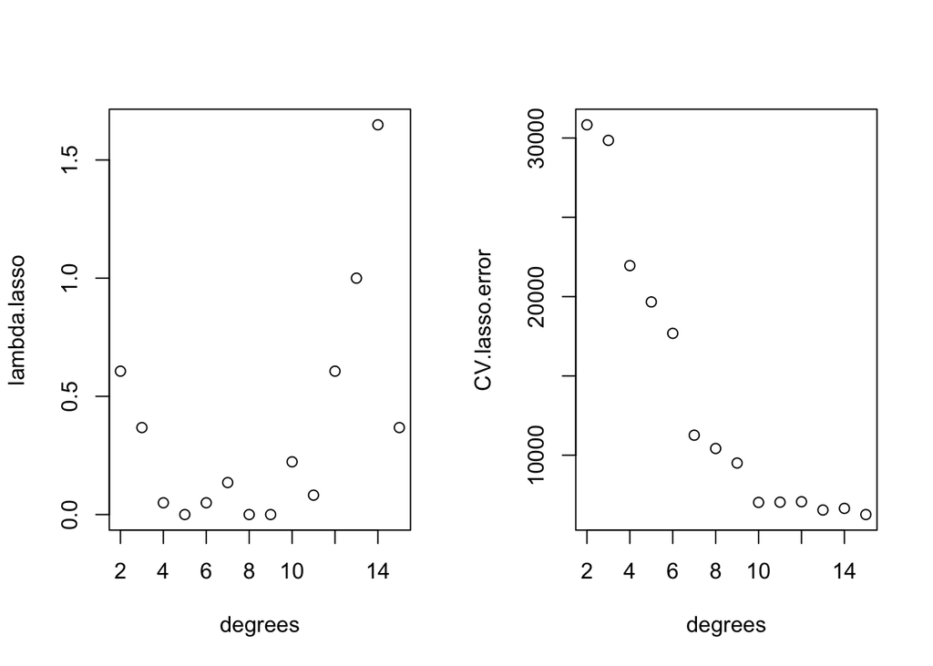

```r
## LASSO
lambda.lasso = c()
CV.lasso.error = c()
for (p in degrees) {
  X = poly(as.vector(time), degree=p, simple=T)
  CV = cv.glmnet(X, as.vector(price), alpha=1, lambda=Lambda.Seq,
                 standardize = T, family = "gaussian")
  lambda.lasso = c(lambda.lasso, CV$lambda.min)
  CV.lasso.error = c(CV.lasso.error, CV$cvm[CV$index[1,1]])
}

par(mfrow=c(1,2))
plot(degrees, lambda.lasso)
plot(degrees, CV.lasso.error)
```

```r
degree.lasso.opt = degrees[which.min(CV.lasso.error)]
lambda.lasso.opt = lambda.lasso[which.min(CV.lasso.error)]
sprintf("The best lasso model is at degree %d with lambda %.4f", degree.lasso.opt, lambda.lasso.opt)
```

```
## [1] "The best lasso model is at degree 15 with lambda 0.3679"
```

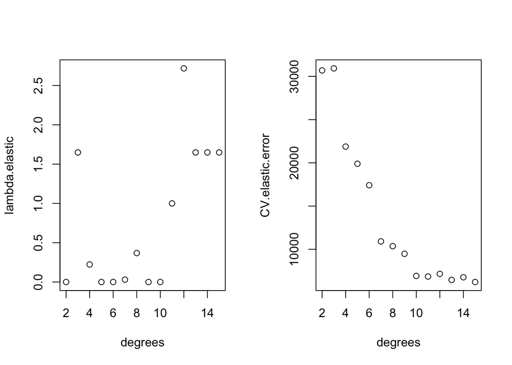

```r
## ELASTIC NET
lambda.elastic = c()
CV.elastic.error = c()
for (p in degrees) {
  X = poly(as.vector(time), degree=p, simple=T)
  CV = cv.glmnet(X, as.vector(price), alpha=0.5, lambda=Lambda.Seq,
                 standardize = T, family = "gaussian")
  lambda.elastic = c(lambda.elastic, CV$lambda.min)
  CV.elastic.error = c(CV.elastic.error, CV$cvm[CV$index[1,1]])
}

par(mfrow=c(1,2))
plot(degrees, lambda.elastic)
plot(degrees, CV.elastic.error)
```